# p-Values

Albert Y. Kim

Mon Nov 14, 2016

## Even vs Odd # of Letters in Last Name

You are given a data set with two variables: 1) even or odd number of letters in last name i.e. two groups and 2) test score. For example, here is an example of what this data would look like, with only 3 rows:

| id | num_letters | test_score |
| --- | --- | --- |
| 1 | even | 0.7 |
| 2 | odd | 0.6 |
| 3 | odd | 0.8 |

Think about how you would test:

- $H_0$: no difference in test scores between odd vs even
- $H_A$: there is a difference

Hints:

- Think about what assuming $H_0$ allows you to do the data set
- Question from Problem Set 08 Question 1.b)

#### 1) Assuming $H_0$ Allows You To…

All hypothesis testing **assumes the null hypothesis is true**. In our case:

1. We assume no difference in test scores between evens and odds
2. So for each student, it doesn’t matter if they have even or odd
3. In other words, the variable `num_letters` is meaningless
4. If `num_letters` is meaningless, then we can **permute** its values to no consequence

Thus assuming $H_0$ is true, the above **observed** data is the same as the following **permuted** data

| id | num_letters | test_score |
| --- | --- | --- |
| 1 | odd | 0.7 |
| 2 | even | 0.6 |
| 3 | odd | 0.8 |

which is the same as the following **permuted** data

| id | num_letters | test_score |
| --- | --- | --- |
| 1 | odd | 0.7 |
| 2 | odd | 0.6 |
| 3 | even | 0.8 |

#### 2) Test Statistic

We need a **test statistic**:

- A **statistic** is just a summary of many values of numbers to a single value. Ex: sum, mean, min, max, median, etc.
- A **test statistic** is simply a statistic used for the purpose of testing.

#### 3) Null Distribution in General

We need a **null distribution**: the typical behavior of the test statistic **assuming $H_0$ is true**. That way we can say how likely/unlikely the observed test statistic is.

Think back to the Lady Tasting Tea example. 8 correct guesses (red line) is unlikely **relative** to the typical number correct if she were guessing at random i.e. the null distribution i.e. the bar plot.

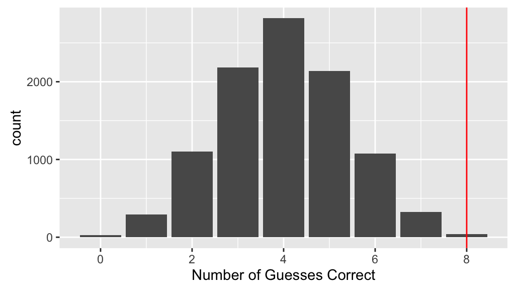

#### 4) Null Distribution in our Case

How do we construct the null distribution in our case? Using **permutations** assuming $H_0$ is true. What is a synonym for permute?